# TFM — SERVICIO DE INSPECCIÓN DEL WASHINGTON COUNTY

El objetivo de este proyecto es generar una herramienta al departamento de salud del King County de Washintgton que facilite tanto el análisis descriptivo de los establecimientos de este condado cuya supervisión les es encomendada, como predictiva ya que busca:

- Analizar características que reúnen los establecimientos con mayor tendencia a la comisión de infracciones.
- Aquellos perfiles con más probabilidades de reincidir.
- Incorporar un mecanismo que les permita agendar las inspecciones en las fechas óptimas en función del riesgo que conlleva cada tipología de establecimiento.

Estos conocimientos, que suelen ser adquiridos por la experiencia de los profesionales al servicio de la administración, ahora se sistematizan, se documentan, y habrán de servir de soporte para la adopción de decisiones por parte de los responsables del servicio. En este sentido, ya existe bibliografía que aboga por la aplicación de las técnicas de aprendizaje automático a esta tipología de establecimientos, con el fin de proporcionar información útil para una planificación de las inspecciones basada en el riesgo.(Oldroyd, R. A., Morris, M. A., & Birkin, M. (2021))

Asimismo, se encuentran entre las finalidades de este estudio:

- Optimizar la planificación de las inspecciones.
- Llevar a cabo una adecuada redistribución de cargas.
- Reducir la curva de aprendizaje de los nuevos empleados en un contexto global de envejecimiento de plantillas.

Para ello, el dataset analizado, de carácter público, se encuentra disponible en data.org y cuenta con más de cien mil registros en los que se detallan las infracciones documentadas, aportando tanto las características de los establecimientos, como su ubicación, tamaño, número de infracciones cometidas, tipología de la inspección, etc. Si bien, como se verá, no todas ellas son igualmente relevantes de cara a los resultados obtenidos.

Nota de funcionamiento: Para facilitar el acceso conectamos primero el notebook con mi repositorio en git, de tal modo que cualquier persona directamente en este [enlace](https://github.com/antigona22ljm-ship-it/TFM) podrá ejecutarlo y tener acceso al dataset utilizado, así como al dashboard de tableau diseñado para facilitar su interpretación y como propuesta inicial de las posibilidades de la solución propuesta.

# Configuración previa

```python
# 0. CONFIGURACIÓN Y CONEXIÓN

from pathlib import Path
import subprocess
import os

# Repositorio público de GitHub
GITHUB_REPO_URL = "https://github.com/antigona22ljm-ship-it/TFM.git"
GITHUB_BRANCH = "main"

# Nombre exacto del fichero de datos almacenado en GitHub
CSV_NAME = "export(12).csv"


PROJECT_DIR = Path("/content/TFM_INSPECCIONES")
REPO_DIR = PROJECT_DIR / "repo"
DATA_DIR = PROJECT_DIR / "datos"
OUTPUT_DIR = PROJECT_DIR / "resultados"

DATA_DIR.mkdir(parents=True, exist_ok=True)
OUTPUT_DIR.mkdir(parents=True, exist_ok=True)

print("=" * 70)
print("CONFIGURACIÓN AUTOMÁTICA DEL PROYECTO")
print("=" * 70)
print("Repositorio:", GITHUB_REPO_URL)
print("Carpeta de trabajo:", PROJECT_DIR)
print("Datos:", DATA_DIR)
print("Resultados:", OUTPUT_DIR)
```

```
======================================================================
CONFIGURACIÓN AUTOMÁTICA DEL PROYECTO
======================================================================
Repositorio: https://github.com/antigona22ljm-ship-it/TFM.git
Carpeta de trabajo: /content/TFM_INSPECCIONES
Datos: /content/TFM_INSPECCIONES/datos
Resultados: /content/TFM_INSPECCIONES/resultados
```

El tamaño del fichero descargado de https://catalog.data.gov obliga a utilizar Git LFS, pero en un entorno administrativo tanto la información como la configuración de los accesos deberá ser objeto de análisis en función de las necesidades.

```python
# 0.1 DESCARGA AUTOMÁTICA DEL REPOSITORIO Y DATOS


print("\nInstalando Git LFS...")
subprocess.run(
    ["bash", "-lc", "apt-get update -qq && apt-get install -y -qq git-lfs"],
    check=True
)

# Inicializamos Git LFS
subprocess.run(["git", "lfs", "install"], check=True)


if not (REPO_DIR / ".git").exists():
    print("Clonando repositorio de GitHub...")
    subprocess.run(
        ["git", "clone", "--branch", GITHUB_BRANCH, GITHUB_REPO_URL, str(REPO_DIR)],
        check=True
    )
else:
    print("El repositorio ya existe. Actualizando...")
    subprocess.run(
        ["git", "-C", str(REPO_DIR), "pull", "--ff-only"],
        check=True
    )


print("Descargando los datos gestionados con Git LFS...")
subprocess.run(["git", "-C", str(REPO_DIR), "lfs", "pull"], check=True)

CSV_PATH = REPO_DIR / CSV_NAME


if not CSV_PATH.exists():
    raise FileNotFoundError(
        f"No se encuentra el archivo de datos: {CSV_PATH}. "
        "Comprueba que el CSV esté incluido en el repositorio de GitHub."
    )

if CSV_PATH.stat().st_size < 1000:
    raise RuntimeError(
               "La descarga mediante Git LFS no se ha completado correctamente."
    )

print("\n Repositorio y datos preparados correctamente.")
print("CSV:", CSV_PATH)
print(f"Tamaño del CSV: {CSV_PATH.stat().st_size / (1024**2):.2f} MB")
```

```
Instalando Git LFS...
El repositorio ya existe. Actualizando...
Descargando los datos gestionados con Git LFS...

 Repositorio y datos preparados correctamente.
CSV: /content/TFM_INSPECCIONES/repo/export(12).csv
Tamaño del CSV: 29.55 MB
```

```python
# 0.2 CARGA DEL DATASET


import pandas as pd

raw_original = pd.read_csv(CSV_PATH, low_memory=False)

print("Archivo cargado correctamente")
print("Filas y columnas:", raw_original.shape)
print("Columnas:")
print(raw_original.columns.tolist())
```

[output not shown]

Se lleva a cabo la importación de librerías, y la configuración básica, sin perjuicio de que en determinados momentos puedan incorporarse elementos adicionales.

Creamos dos carpetas, una de datos y otra para resultados, con el fin de contar de forma separada con los archivos, y poder compartir con negocio la información que les será de utilidad para explotarla en el dashboard complementario de este análisis.

```python
# 1. LIBRERÍAS

!pip -q install xgboost openpyxl seaborn scikit-learn pandas numpy matplotlib
```

Del trabajo preliminar de estudio de los datos que se acompaña como anexo, hemos podido concluir que existen determinados establecimientos que no son objeto de clasificación en determinadas variables. De mantener su tratamiento idéntico en todos los casos, los resultados obtenidos se verían necesariamente distorsionados, por lo que, desde un principio, los agrupamos en una lista porque se van a utilizar en el análisis como un bloque. De este modo, si en el futuro se ampliara el listado de establecimientos que contienen registros en todas las variables, podrá ampliarse, o reducirse, esta lista inicial, sin perjuicio de poder crear otras similares, lo que permite que la herramienta resulte más fácil de actualizar de cara a futuras necesidades.

Indicar que se acompaña como anexo, para lograr aquí un código más limpio, el trabajo realizado para cada una de las variables y en el que se podrá ver en detalle los pasos que se han seguido tanto para la adopción de esta decisión, como la de todas y cada una de las operaciones de limpieza y depuración del dataset.

```python
# 2. CONFIGURACIÓN

from pathlib import Path
import re
import warnings
warnings.filterwarnings('ignore')

import numpy as np
import pandas as pd
import matplotlib.pyplot as plt
from sklearn.compose import ColumnTransformer
from sklearn.pipeline import Pipeline
from sklearn.preprocessing import OneHotEncoder
from sklearn.impute import SimpleImputer
from sklearn.ensemble import RandomForestClassifier, ExtraTreesClassifier
from sklearn.metrics import (
    roc_auc_score, average_precision_score, brier_score_loss,
    classification_report, confusion_matrix
)
from sklearn.calibration import calibration_curve
from xgboost import XGBClassifier

RANDOM_STATE = 42
TEST_FRACTION = 0.20
MIN_GROUP_SIZE = 20

# Listado de categorías que no registran calificacion en grade

CLASIFICACIONES_SIN_NOTA = [
    'school lunch program',
    'grocery store',
    'nonprofit institution',
    'bed and breakfast operation',
    'commissary kitchen',
    'dfdo exempt from billing',
    'commissary kitchen exempt from',
]

INTERVAL_CANDIDATES = list(range(30, 731, 30))

print('Librerías cargadas correctamente.')
```

```
Librerías cargadas correctamente.
```

# Análisis

El dataset inicial cuenta con 106995 filas y 20 columnas.

Durante el proceso de elaboración del trabajo se han ido probando distintos mecanismos, descartando aquellas soluciones que no dieron resultado (pej. Id_business para depurar los nulos de city en el dataset. Estas pruebas han sido descartadas en el código final.

Los datos básicos relativos a la tipología de los datos, y el número de registros nulos encontrados son los siguientes:

```python
print('\nInformación del DataFrame (columnas y tipos):')
display(raw_original.info())

print('\nNúmero y porcentaje de nulos por columna en raw_original:')
null_counts = raw_original.isna().sum()
null_percentages = (raw_original.isna().sum() / len(raw_original) * 100).round(2)
null_info = pd.DataFrame({'n_null': null_counts, 'pct_null': null_percentages})
display(null_info[null_info['n_null'] > 0].sort_values(by='n_null', ascending=False))
```

```
Información del DataFrame (columnas y tipos):
<class 'pandas.core.frame.DataFrame'>
RangeIndex: 106995 entries, 0 to 106994
Data columns (total 20 columns):
 #   Column                      Non-Null Count   Dtype
---  ------                      --------------   -----
 0   Name                        106995 non-null  object
 1   Program Identifier          19519 non-null   object
 2   Inspection Date             106995 non-null  object
 3   Classification              106995 non-null  object
 4   Address                     106994 non-null  object
 5   City                        106987 non-null  object
 6   Zip Code                    106994 non-null  object
 7   Inspection Type             106995 non-null  object
 8   Inspection Score            106995 non-null  int64
 9   Inspection Result           106995 non-null  object
 10  Inspection Closed Business  106995 non-null  object
 11  Seating Range               83706 non-null   object
 12  Risk Category               106369 non-null  float64
 13  Violation Type              67185 non-null   object
 14  Violation Description       67185 non-null   object
 15  Violation Points            106995 non-null  int64
 16  Grade                       106995 non-null  object
 17  Parcel Number               106637 non-null  object
 18  Business_ID                 106995 non-null  object
 19  Inspection_Serial_Num       106995 non-null  object
dtypes: float64(1), int64(2), object(17)
memory usage: 16.3+ MB
```

```
None
```

```
Número y porcentaje de nulos por columna en raw_original:
```

|  | n_null | pct_null |
| --- | --- | --- |
| Program Identifier | 87476 | 81.76 |
| Violation Description | 39810 | 37.21 |
| Violation Type | 39810 | 37.21 |
| Seating Range | 23289 | 21.77 |
| Risk Category | 626 | 0.59 |
| Parcel Number | 358 | 0.33 |
| City | 8 | 0.01 |
| Zip Code | 1 | 0.00 |
| Address | 1 | 0.00 |

El alto porcentaje de valores nulos en la variable program identifier hace necesario valorar su eliminación. En los trabajos preparatorios se estudió si podía recuperarse de algún modo, pero se descartó.

Por otro lado, adelantar que los nulos más relevantes no son tales:

- en Violation Type y Violation Description simplemente se trataría de actas satisfactorias en las que no existiría ninguna infracción documentada.
- en seating range, se trata de una variable que no resulta de aplicación a determinadas categorías de establecimientos, por lo que tampoco nos encontraríamos ante ese problema.

El análisis del resto de los valores nulos se abordará más adelante.

```python
raw_original.head()
```

|  | Name | Program Identifier | Inspection Date | Classification | Address | City | Zip Code | Inspection Type | Inspection Score | Inspection Result | Inspection Closed Business | Seating Range | Risk Category | Violation Type | Violation Description | Violation Points | Grade | Parcel Number | Business_ID | Inspection_Serial_Num |
| --- | --- | --- | --- | --- | --- | --- | --- | --- | --- | --- | --- | --- | --- | --- | --- | --- | --- | --- | --- | --- |
| 0 | #807 TUTTA BELLA | NaN | 05/28/2026 | General Food Services | 2746 NE 45TH ST | SEATTLE | 98105 | Routine Inspection/Field Review | 0 | Satisfactory | No | 0-12 | 3.0 | NaN | NaN | 0 | Excellent | 0925049330 | PFE-PR-3147569 | PFE-RT-0465692-2025 |
| 1 | #807 TUTTA BELLA | NaN | 12/23/2025 | General Food Services | 2746 NE 45TH ST | SEATTLE | 98105 | Educational Inspection | 0 | Complete | No | 0-12 | 3.0 | NaN | NaN | 0 | Excellent | 0925049330 | PFE-PR-3147569 | PFE-EDU-104561-2025 |
| 2 | #807 TUTTA BELLA | NaN | 08/15/2025 | General Food Services | 2746 NE 45TH ST | SEATTLE | 98105 | Routine Inspection/Field Review | 0 | Satisfactory | No | 0-12 | 3.0 | NaN | NaN | 0 | Excellent | 0925049330 | PFE-PR-3147569 | PFE-DAXHJEKXU |
| 3 | #807 TUTTA BELLA | NaN | 03/24/2025 | General Food Services | 2746 NE 45TH ST | SEATTLE | 98105 | Routine Inspection/Field Review | 5 | Unsatisfactory | No | 0-12 | 3.0 | RED | 2120 - Proper cold holding temperatures; betwe... | 5 | Excellent | 0925049330 | PFE-PR-3147569 | PFE-DA05TOC3V |
| 4 | #807 TUTTA BELLA | NaN | 08/02/2024 | General Food Services | 2746 NE 45TH ST | SEATTLE | 98105 | Routine Inspection/Field Review | 15 | Unsatisfactory | No | 0-12 | 3.0 | BLUE | 3400 - Wiping cloths properly used, stored; sa... | 5 | Excellent | 0925049330 | PFE-PR-3147569 | PFE-DAPY60A5G |

Como el objetivo último del trabajo es contar con una herramienta que sea capaz de predecir las posibilidades de que la siguiente inspección tenga o no carácter satisfactorio, el primer punto en el que nos centramos en esa variable objetivo.

```python
# primera aproximación al número de infracciones insatisfactorias

print(raw_original['Inspection Result'].value_counts())

print("n\Porcentajes:\n")
print(round(raw_original["Inspection Result"].value_counts(normalize=True)*100,2))
```

```
Inspection Result
Satisfactory      52363
Unsatisfactory    52185
Complete           2447
Name: count, dtype: int64
n\Porcentajes:

Inspection Result
Satisfactory      48.94
Unsatisfactory    48.77
Complete           2.29
Name: proportion, dtype: float64
```

Y destaca que no se trata de una variable dicotómica, sino que existe una tercera opción, netamente minoritaria, que se denomina "complete". De su análisis se concluye que realmente se trata de inspecciones que pueden o no resultar satisfactorias o insatisfactorias, por lo que, a la vista de los datos que en ella se contemplan, se agruparán en una de las dos clases anteriores (satisfactorias- insatisfactorias)

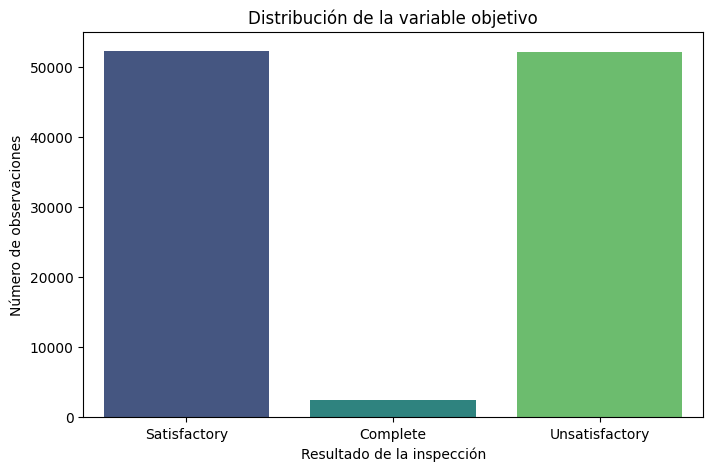

```python
import seaborn as sns
plt.figure(figsize=(8,5))

sns.countplot(
    data=raw_original,
    x="Inspection Result",
    palette="viridis"
)

plt.title("Distribución de la variable objetivo")
plt.xlabel("Resultado de la inspección")
plt.ylabel("Número de observaciones")

plt.show()
```

Aunque aparentemente parecieran balanceadas, la existencia de 16 mil actas que documentan más de una infracción hará que se incline la balanza hacia los resultados satisfactorios. Este elemento de que existan actas con más de una infracción documentada, será clave de cara a la toma de decisiones y la planificación se concentre a nivel acta, y no a nivel infracción como se refleja en el dataset original.

El siguiente paso será analizar la tipología de las variables con las que contamos para realizar el análisis.

```python
numericas=raw_original.select_dtypes(include=["int64","float64"]).columns
categoricas=raw_original.select_dtypes(include=["object"]).columns

print(f"Número de variables numéricas: {len(numericas)}")

print(f"Número de variables categóricas: {len(categoricas)}")
```

```
Número de variables numéricas: 3
Número de variables categóricas: 17
```

```python
print("Variables numéricas")

display(pd.DataFrame(numericas,columns=["Variable"]))

print("\n")

print("Variables categóricas")

display(pd.DataFrame(categoricas,columns=["Variable"]))
```

```
Variables numéricas
```

|  | Variable |
| --- | --- |
| 0 | Inspection Score |
| 1 | Risk Category |
| 2 | Violation Points |

```
Variables categóricas
```

|  | Variable |
| --- | --- |
| 0 | Name |
| 1 | Program Identifier |
| 2 | Inspection Date |
| 3 | Classification |
| 4 | Address |
| 5 | City |
| 6 | Zip Code |
| 7 | Inspection Type |
| 8 | Inspection Result |
| 9 | Inspection Closed Business |
| 10 | Seating Range |
| 11 | Violation Type |
| 12 | Violation Description |
| 13 | Grade |
| 14 | Parcel Number |
| 15 | Business_ID |
| 16 | Inspection_Serial_Num |

```python
# descripción de las variables

raw_original[numericas].describe().T
```

|  | count | mean | std | min | 25% | 50% | 75% | max |
| --- | --- | --- | --- | --- | --- | --- | --- | --- |
| Inspection Score | 106995.0 | 15.573999 | 21.398284 | -1.0 | 0.0 | 8.0 | 23.0 | 167.0 |
| Risk Category | 106369.0 | 2.771165 | 0.563647 | 1.0 | 3.0 | 3.0 | 3.0 | 3.0 |
| Violation Points | 106995.0 | 4.614739 | 5.737085 | 0.0 | 0.0 | 5.0 | 5.0 | 25.0 |

```python
raw_original[categoricas].describe().T
```

|  | count | unique | top | freq |
| --- | --- | --- | --- | --- |
| Name | 106995 | 9846 | LEVY RESTAURANTS @ LUMEN FIELD | 723 |
| Program Identifier | 19519 | 2390 | LUNCHROOM | 1087 |
| Inspection Date | 106995 | 1666 | 06/10/2026 | 221 |
| Classification | 106995 | 15 | General Food Services | 83214 |
| Address | 106994 | 9484 | 800 OCCIDENTAL AVE S | 829 |
| City | 106987 | 111 | SEATTLE | 37451 |
| Zip Code | 106994 | 131 | 98101 | 4210 |
| Inspection Type | 106995 | 3 | Routine Inspection/Field Review | 102360 |
| Inspection Result | 106995 | 3 | Satisfactory | 52363 |
| Inspection Closed Business | 106995 | 2 | No | 106820 |
| Seating Range | 83706 | 5 | 13-50 | 30436 |
| Violation Type | 67185 | 2 | BLUE | 33735 |
| Violation Description | 67185 | 53 | 3400 - Wiping cloths properly used, stored; sa... | 6797 |
| Grade | 106995 | 6 | Excellent | 45285 |
| Parcel Number | 106637 | 6258 | 7666204876 | 829 |
| Business_ID | 106995 | 12299 | PFE-PR-3128874 | 115 |
| Inspection_Serial_Num | 106995 | 72070 | PFE-DAGM7JOI4 | 19 |

```python
# y la cardinalidad

valores_unicos = pd.DataFrame({
    "Variable": raw_original.columns,
    "Valores únicos": raw_original.nunique().values
})

valores_unicos.sort_values(
    by="Valores únicos",
    ascending=False
)
```

|  | Variable | Valores únicos |
| --- | --- | --- |
| 19 | Inspection_Serial_Num | 72070 |
| 18 | Business_ID | 12299 |
| 0 | Name | 9846 |
| 4 | Address | 9484 |
| 17 | Parcel Number | 6258 |
| 1 | Program Identifier | 2390 |
| 2 | Inspection Date | 1666 |
| 6 | Zip Code | 131 |
| 8 | Inspection Score | 127 |
| 5 | City | 111 |
| 14 | Violation Description | 53 |
| 3 | Classification | 15 |
| 15 | Violation Points | 7 |
| 16 | Grade | 6 |
| 11 | Seating Range | 5 |
| 7 | Inspection Type | 3 |
| 12 | Risk Category | 3 |
| 9 | Inspection Result | 3 |
| 10 | Inspection Closed Business | 2 |
| 13 | Violation Type | 2 |

```python
constantes = []

for col in raw_original.columns:

    if raw_original[col].nunique()==1:

        constantes.append(col)

print(constantes)

casi_constantes=[]

for col in raw_original.columns:

    frecuencia=raw_original[col].value_counts(normalize=True).iloc[0]

    if frecuencia>0.90:

        casi_constantes.append(col)

print(casi_constantes)
```

```
[]
['Inspection Type', 'Inspection Closed Business']
```

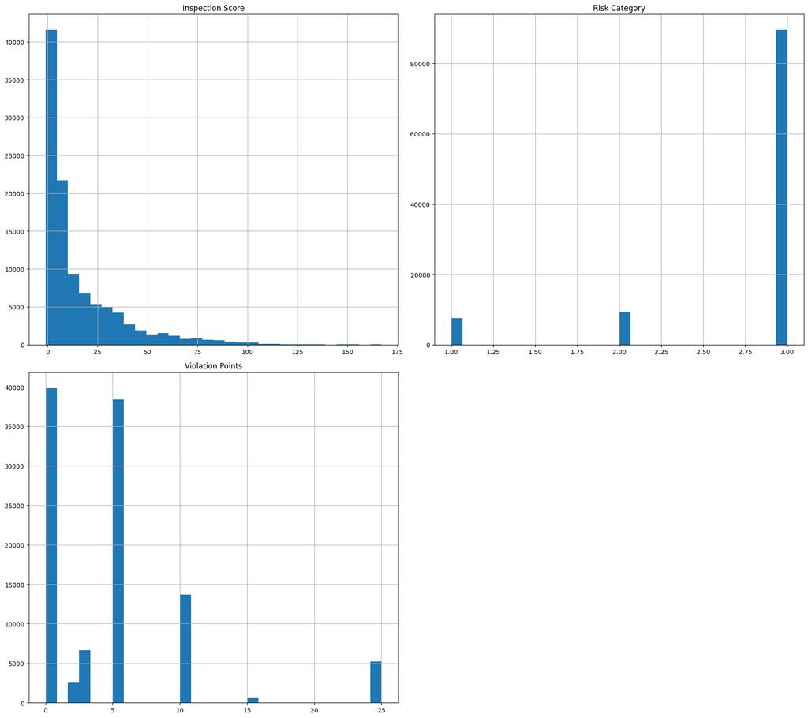

```python
# visualizamos esta información

numericas = raw_original.select_dtypes(include=["int64","float64"]).columns

raw_original[numericas].hist(
    figsize=(18,16),
    bins=30
)

plt.tight_layout()

plt.show()
```

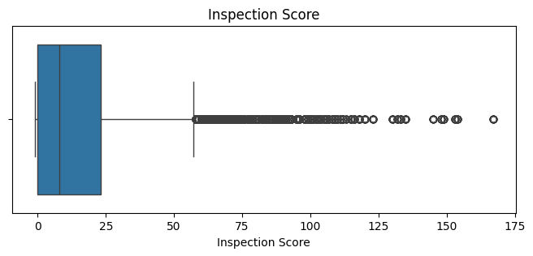

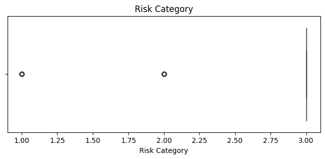

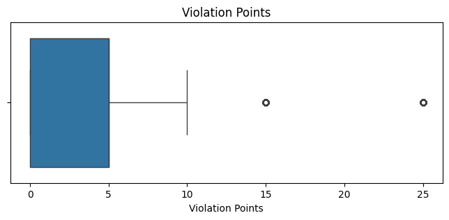

```python
for columna in numericas:

    plt.figure(figsize=(8,3))

    sns.boxplot(
        x=raw_original[columna]
    )

    plt.title(columna)

    plt.show()
```

Con esta representación podemos adelantar que junto con establecimientos, los menos, que concentran gran número de infracciones, y que podrían llegar a ser objeto de un tratamiento separado, el grueso del trabajo de los inspectores se centrará en dedicar sus esfuerzos a un colectivo numeroso de establecimientos que concentran menor número de infracciones (5), pero que cuantitativamente agrupan valores altos.

También analizamos la posible correlación entre las variables numéricas para decidir cuál debe ser su tratamiento.

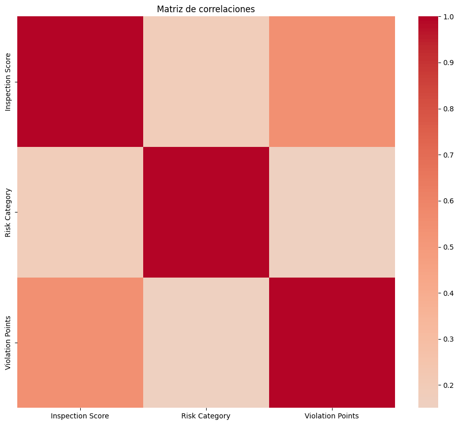

```python
corr = raw_original[numericas].corr()

plt.figure(figsize=(12,10))

sns.heatmap(
    corr,
    cmap="coolwarm",
    center=0
)

plt.title("Matriz de correlaciones")

plt.show()
```

```python
# pero descartamos la correlación

corr_matrix = raw_original[numericas].corr().abs()

upper = corr_matrix.where(
    np.triu(np.ones(corr_matrix.shape),k=1).astype(bool)
)

correladas = []

for columna in upper.columns:

    if any(upper[columna]>0.90):

        correladas.append(columna)

print(correladas)
```

```
[]
```

Las variables categóricas, por su gran cardinalidad en este dataset, ofrecen innegables dificultades, especialmente porque nos enfrentamos al reto de que la información permita bajar al detalle que permita disponer a los inspectores de criterios adaptados tanto a la localización, la tipología o la cualesquiera otro criterio que pudiera resultar decisivo de cara la optimización de la inspección de los establecimientos.

```python
for columna in categoricas:

    print("="*60)
    print(columna)
    print("="*60)

    display(raw_original[columna].value_counts().head(10))

    print("\n")
```

```
============================================================
Name
============================================================
```

| Name | count |
| --- | --- |
| LEVY RESTAURANTS @ LUMEN FIELD | 723 |
| T-MOBILE PARK | 592 |
| ARENA AT SEATTLE CENTER | 436 |
| SUBWAY | 319 |
| PCC COMMUNITY MARKETS | 283 |
| TACO TIME | 259 |
| PAGLIACCI PIZZA INC | 185 |
| WENDY'S | 175 |
| WHOLE FOODS MARKET | 171 |
| FACEBOOK INC | 155 |

**dtype:** int64

```
============================================================
Program Identifier
============================================================
```

| Program Identifier | count |
| --- | --- |
| LUNCHROOM | 1087 |
| QFC - GROCERY | 76 |
| GROCERY | 61 |
| PCC COMMUNITY MARKETS - DELI | 53 |
| TAQUERIA EL HERRADERO LLC (KC242)@2800 NE SUNSET | 48 |
| SAFEWAY STORE #1508 | 44 |
| UWAJIMAYA - DELI | 43 |
| FOU LEE MARKET & DELI | 42 |
| DELI | 41 |
| HUNG LONG MARKET - MEAT/SEAFOOD | 40 |

**dtype:** int64

```
============================================================
Inspection Date
============================================================
```

| Inspection Date | count |
| --- | --- |
| 06/10/2026 | 221 |
| 03/27/2025 | 198 |
| 06/08/2026 | 198 |
| 03/24/2026 | 187 |
| 03/11/2025 | 183 |
| 02/27/2025 | 178 |
| 02/25/2025 | 178 |
| 06/09/2026 | 175 |
| 04/16/2025 | 172 |
| 04/24/2025 | 170 |

**dtype:** int64

```
============================================================
Classification
============================================================
```

| Classification | count |
| --- | --- |
| General Food Services | 83214 |
| Grocery Store | 5024 |
| School Lunch Program | 4790 |
| Meat/Fish Market | 4062 |
| Mobile Food Unit | 3983 |
| Nonprofit Institution | 1873 |
| Bakery | 1472 |
| Catering Operation | 1388 |
| Limited Food Service | 540 |
| General Food Service | 507 |

**dtype:** int64

```
============================================================
Address
============================================================
```

| Address | count |
| --- | --- |
| 800 OCCIDENTAL AVE S | 829 |
| 1250 1ST AVE S | 663 |
| 334 1ST AVE N | 436 |
| 10836 E MARGINAL WAY S | 270 |
| 17801 INTERNATIONAL BLVD | 207 |
| 19600 144TH AVE NE | 175 |
| 360 CORPORATE DR N | 173 |
| 36201 ENCHANTED PKWY S | 128 |
| 305 HARRISON ST | 127 |
| 5604 DELRIDGE WAY SW | 121 |

**dtype:** int64

```
============================================================
City
============================================================
```

| City | count |
| --- | --- |
| SEATTLE | 37451 |
| Seattle | 12191 |
| BELLEVUE | 7057 |
| KENT | 5163 |
| FEDERAL WAY | 3869 |
| REDMOND | 3581 |
| RENTON | 3496 |
| KIRKLAND | 3035 |
| TUKWILA | 2647 |
| AUBURN | 2458 |

**dtype:** int64

```
============================================================
Zip Code
============================================================
```

| Zip Code | count |
| --- | --- |
| 98101 | 4210 |
| 98052 | 4018 |
| 98105 | 3932 |
| 98104 | 3762 |
| 98122 | 3732 |
| 98003 | 3685 |
| 98109 | 3419 |
| 98032 | 3278 |
| 98004 | 3041 |
| 98118 | 2822 |

**dtype:** int64

```
============================================================
Inspection Type
============================================================
```

| Inspection Type | count |
| --- | --- |
| Routine Inspection/Field Review | 102360 |
| Return Inspection | 2790 |
| Educational Inspection | 1845 |

**dtype:** int64

```
============================================================
Inspection Result
============================================================
```

| Inspection Result | count |
| --- | --- |
| Satisfactory | 52363 |
| Unsatisfactory | 52185 |
| Complete | 2447 |

**dtype:** int64

```
============================================================
Inspection Closed Business
============================================================
```

| Inspection Closed Business | count |
| --- | --- |
| No | 106820 |
| Yes | 175 |

**dtype:** int64

```
============================================================
Seating Range
============================================================
```

| Seating Range | count |
| --- | --- |
| 13-50 | 30436 |
| 0-12 | 23852 |
| 51-150 | 23412 |
| 151-250 | 3776 |
| > 250 | 2230 |

**dtype:** int64

```
============================================================
Violation Type
============================================================
```

| Violation Type | count |
| --- | --- |
| BLUE | 33735 |
| RED | 33450 |

**dtype:** int64

```
============================================================
Violation Description
============================================================
```

| Violation Description | count |
| --- | --- |
| 3400 - Wiping cloths properly used, stored; sanitizer concentration | 6797 |
| 0600 - Adequate handwashing facilities | 4775 |
| 2110 - Proper cold holding temperatures; greater than 45 degrees Fahrenheit (F) (7 degrees Celsius (C)) | 4518 |
| 4100 - Warewashing facilities properly installed, maintained, used; sanitizer concentration; test strips available and used | 4453 |
| 2120 - Proper cold holding temperatures; between 42 to 45 degrees Fahrenheit (F) (6 to 7 degrees Celsius (C)) | 3865 |
| 3300 - Potential food contamination prevented during delivery, preparation, storage, display | 3076 |
| 4200 - Food-contact surfaces maintained, cleaned, sanitized | 3073 |
| 0100 - PIC present, demonstrates knowledge and performs duties to maintain AMC; certified manager on staff unless exempt | 2540 |
| 1400 - Raw meats below and away from ready-to-eat food; species separated | 2461 |
| 4300 - Nonfood-contact surfaces maintained and clean | 2366 |

**dtype:** int64

```
============================================================
Grade
============================================================
```

| Grade | count |
| --- | --- |
| Excellent | 45285 |
| Good | 32407 |
| Okay | 15708 |
| Not Rated | 12036 |
| Needs To Improve | 1223 |
| Rating Not Available | 336 |

**dtype:** int64

```
============================================================
Parcel Number
============================================================
```

| Parcel Number | count |
| --- | --- |
| 7666204876 | 829 |
| 2823049016 | 678 |
| 7666206483 | 670 |
| 1985200003 | 442 |
| 9202470010 | 393 |
| 2725059039 | 393 |
| 2625059123 | 330 |
| 0924059100 | 299 |
| 1544100040 | 296 |
| 0323049164 | 296 |

**dtype:** int64

```
============================================================
Business_ID
============================================================
```

| Business_ID | count |
| --- | --- |
| PFE-PR-3128874 | 115 |
| PFE-PR-3127355 | 105 |
| PFE-PR-3137682 | 100 |
| PFE-PR-3144069 | 99 |
| PFE-PR-3127686 | 79 |
| PFE-PR-3143924 | 71 |
| PFE-PR-3139404 | 71 |
| PFE-PR-3143306 | 65 |
| PFE-PR-3129029 | 65 |
| PFE-PR-3145493 | 61 |

**dtype:** int64

```
============================================================
Inspection_Serial_Num
============================================================
```

| Inspection_Serial_Num | count |
| --- | --- |
| PFE-DAGM7JOI4 | 19 |
| PFE-DAPA0QENU | 19 |
| PFE-DAXK1YYUE | 18 |
| PFE-DAS3YBJ3Z | 16 |
| PFE-DAIIVHGVL | 16 |
| PFE-RT-0459028-2025 | 16 |
| PFE-DAN2BM0IB | 16 |
| PFE-DAVRBVMYG | 16 |
| PFE-DAMT3C0KE | 16 |
| PFE-DAPXOCVNH | 16 |

**dtype:** int64

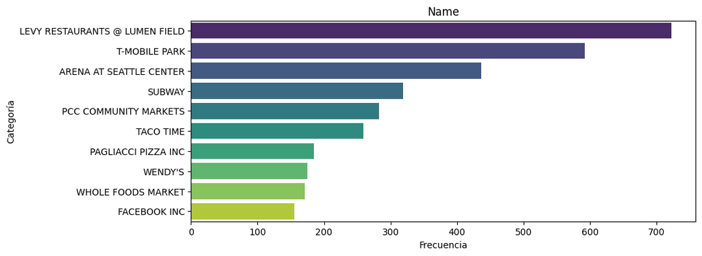

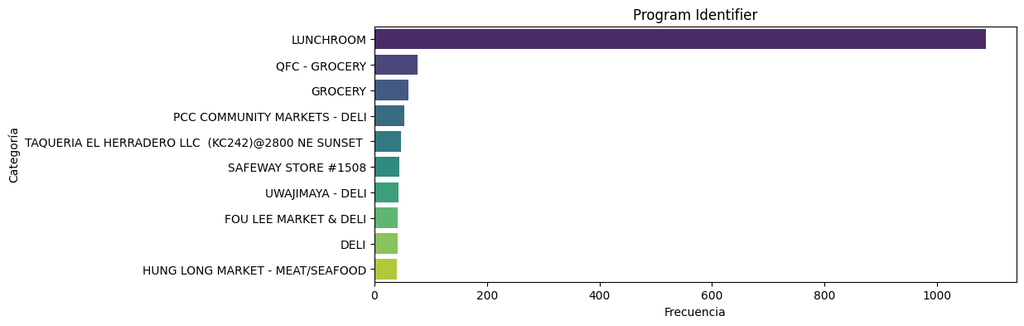

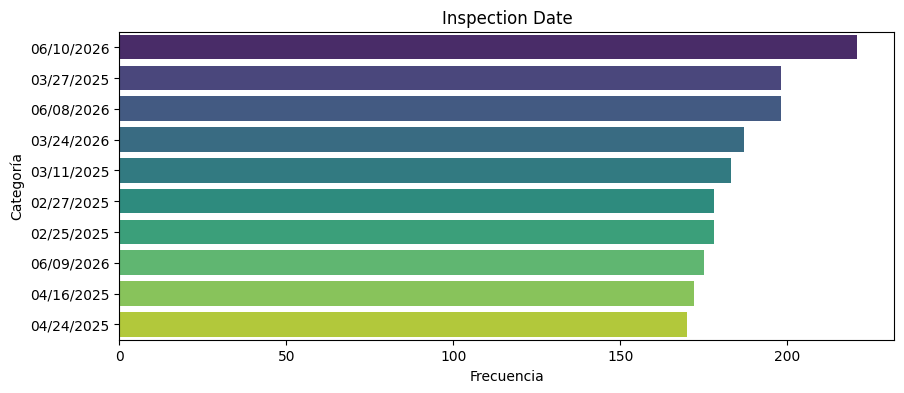

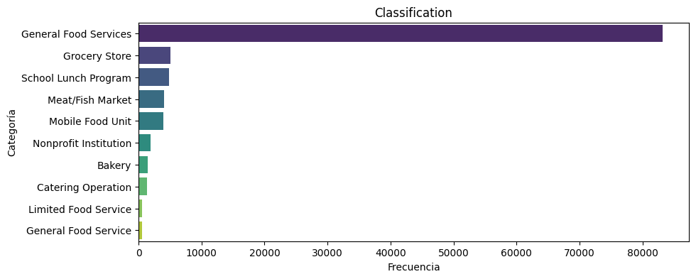

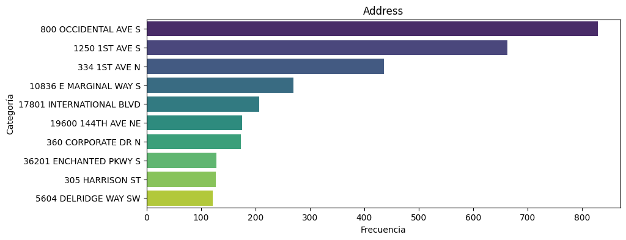

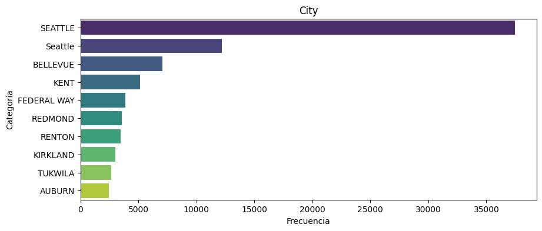

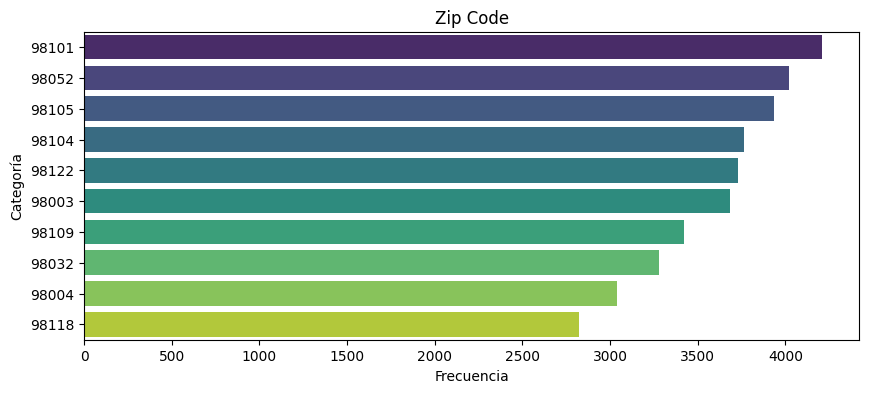

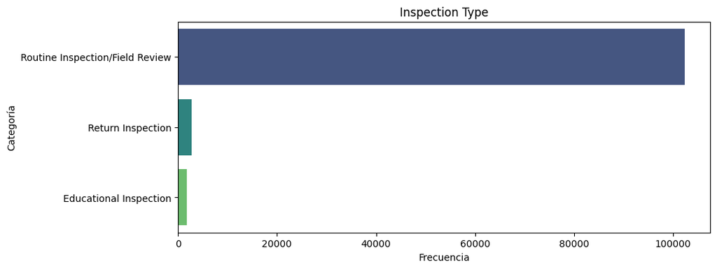

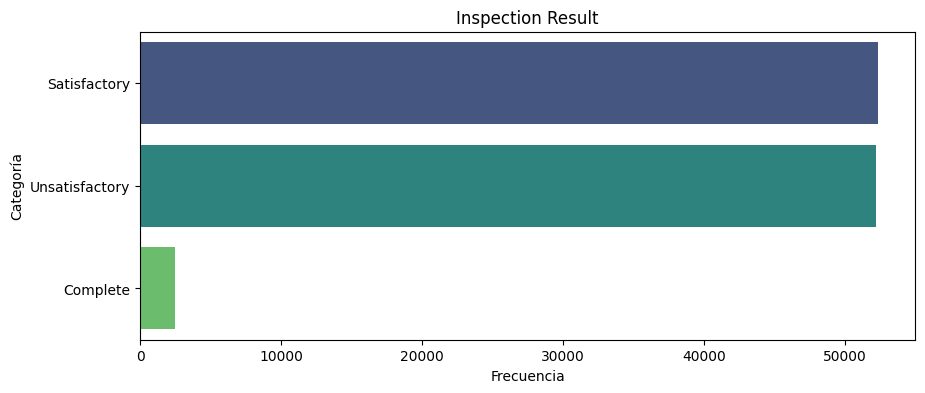

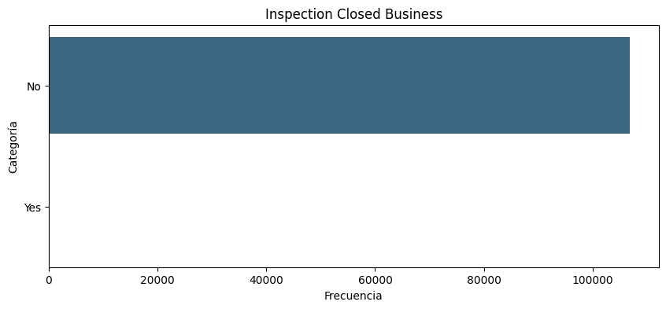

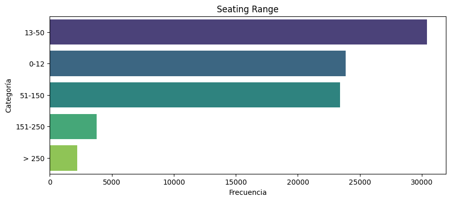

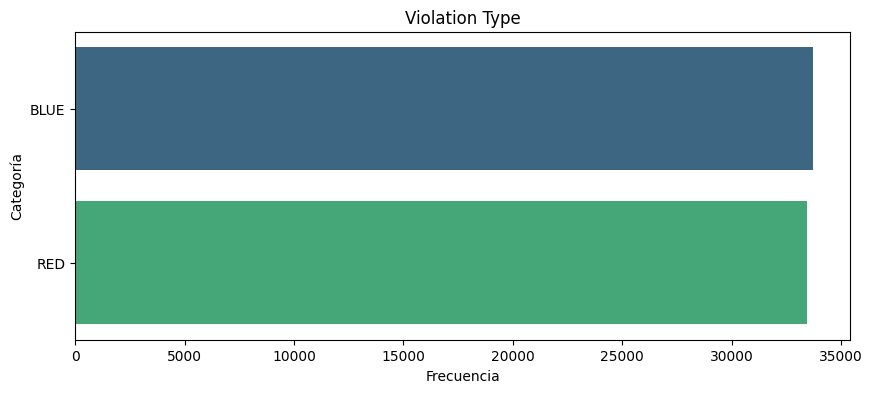

[5 more figures not shown]

```python
for columna in categoricas:

    plt.figure(figsize=(10,4))

    top = raw_original[columna].value_counts().head(10)

    sns.barplot(

        x=top.values,

        y=top.index,

        palette="viridis"

    )

    plt.title(columna)

    plt.xlabel("Frecuencia")

    plt.ylabel("Categoría")

    plt.show()
```

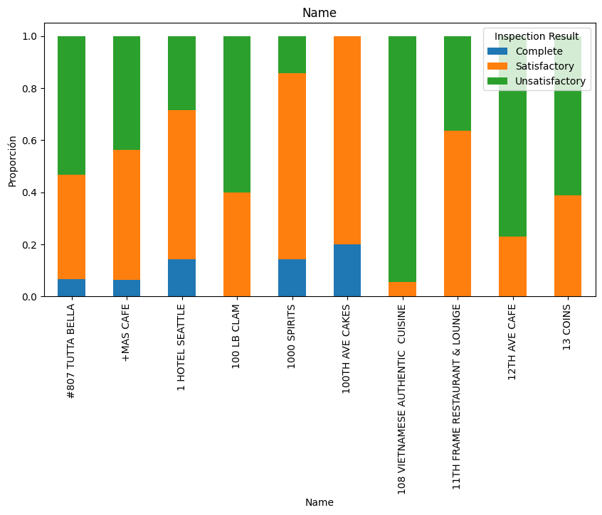

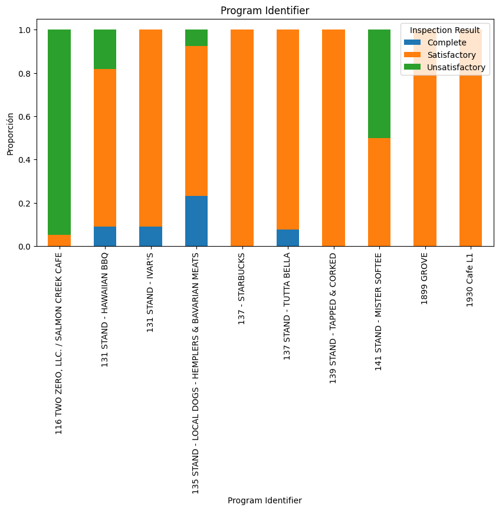

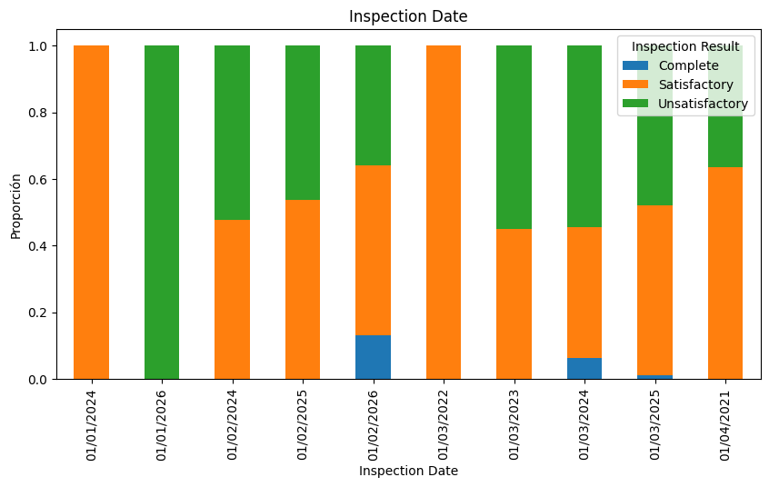

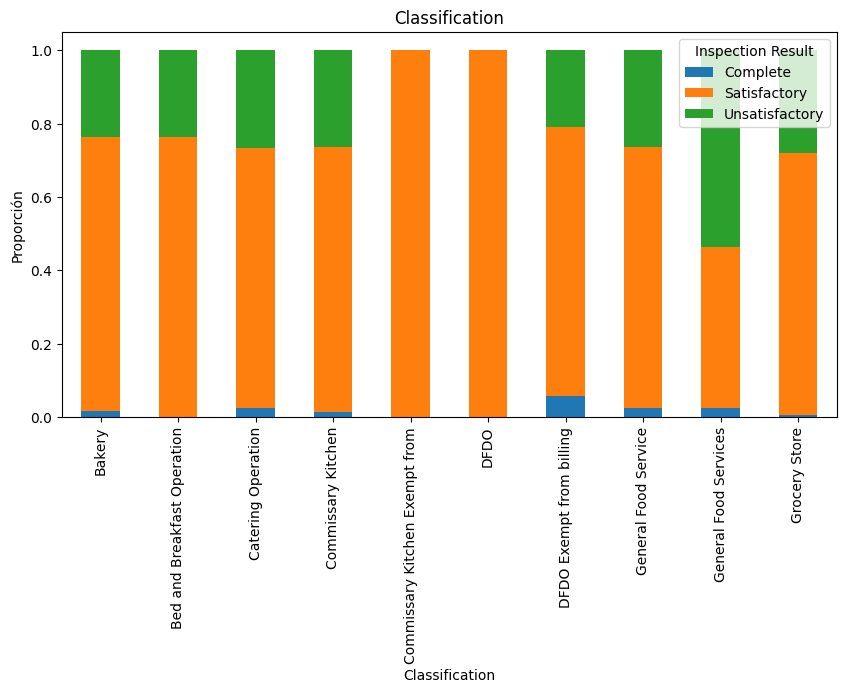

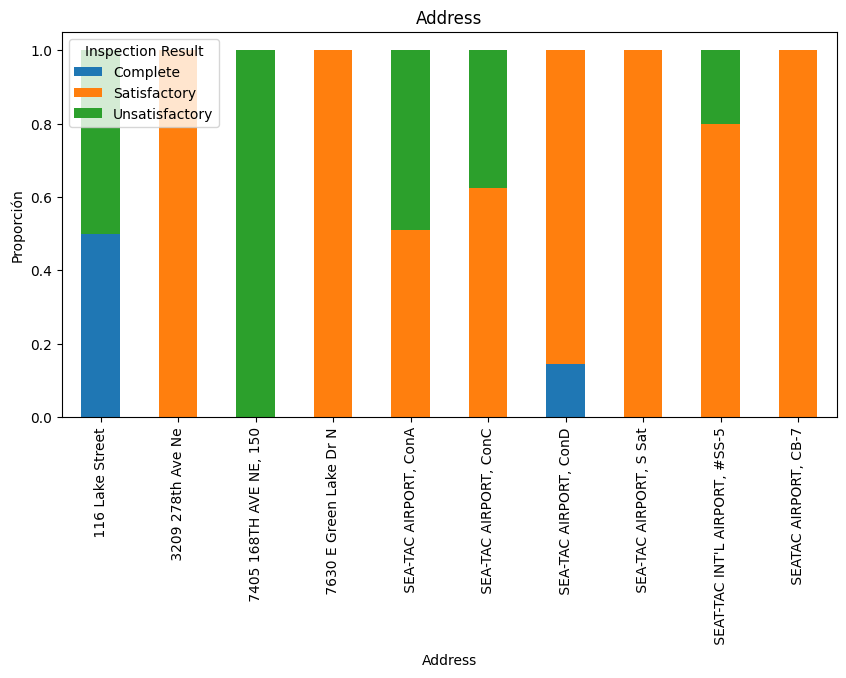

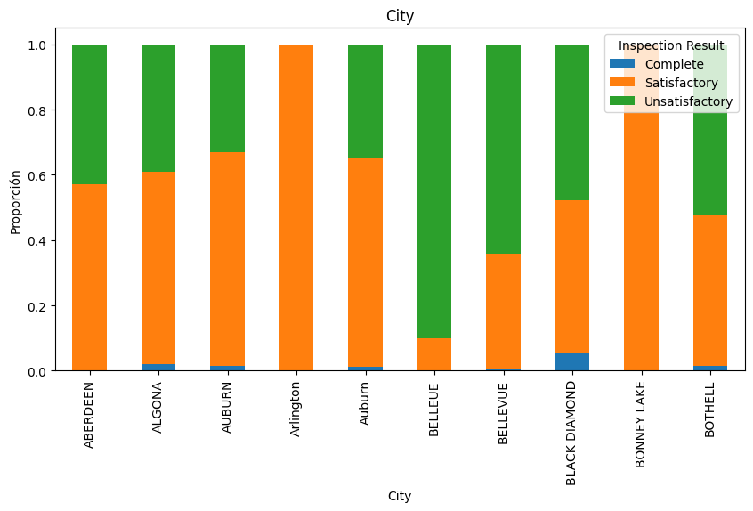

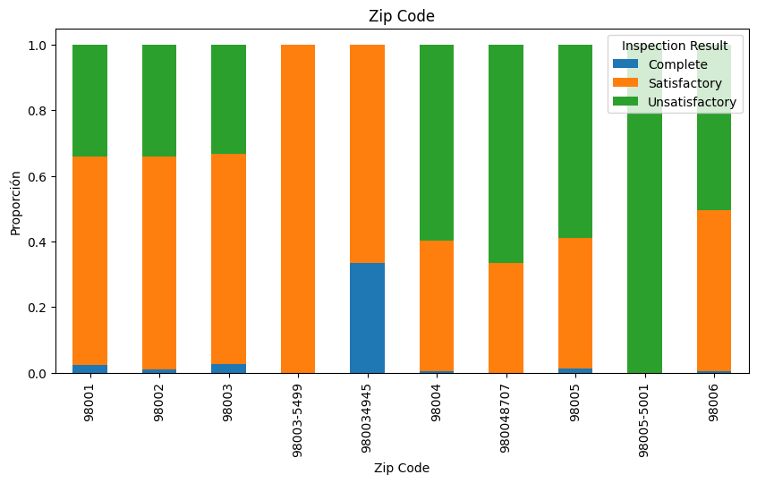

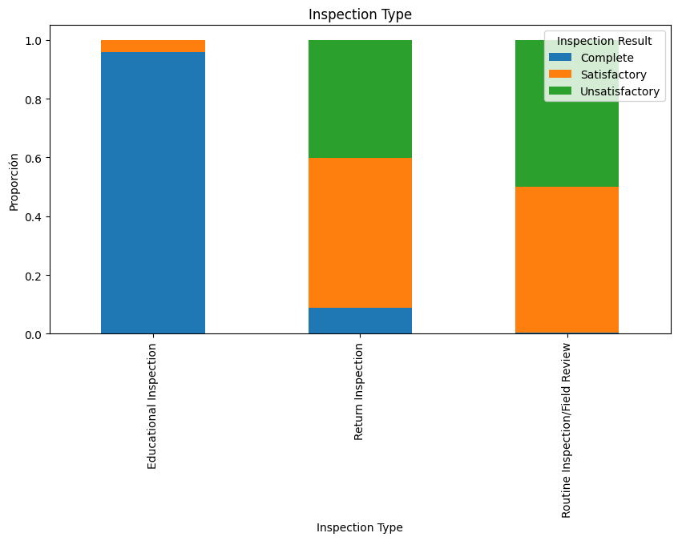

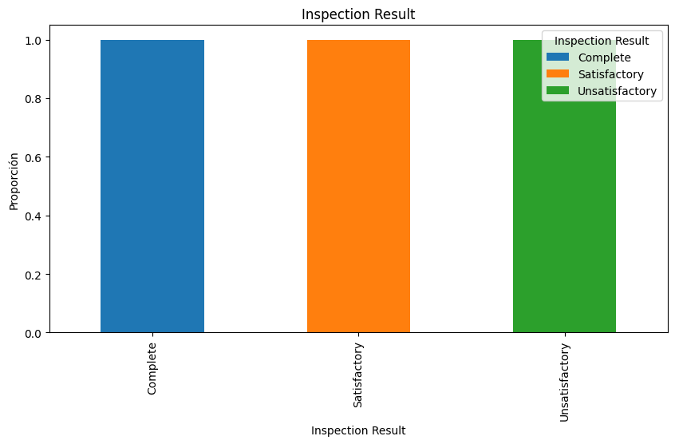

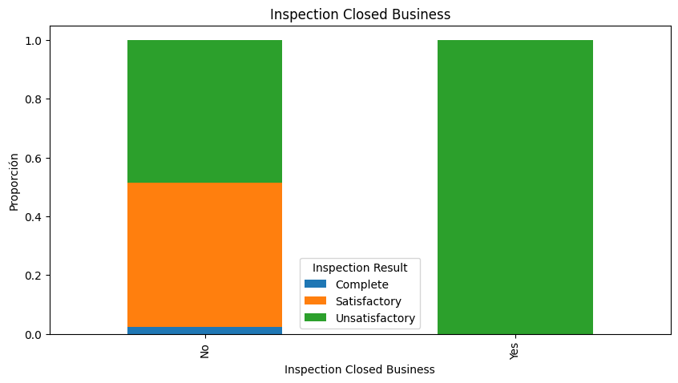

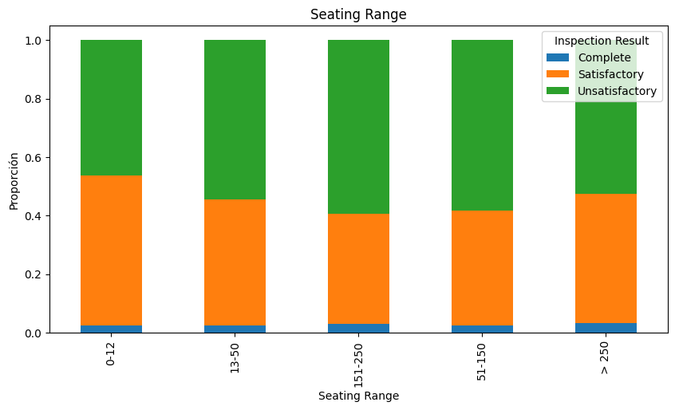

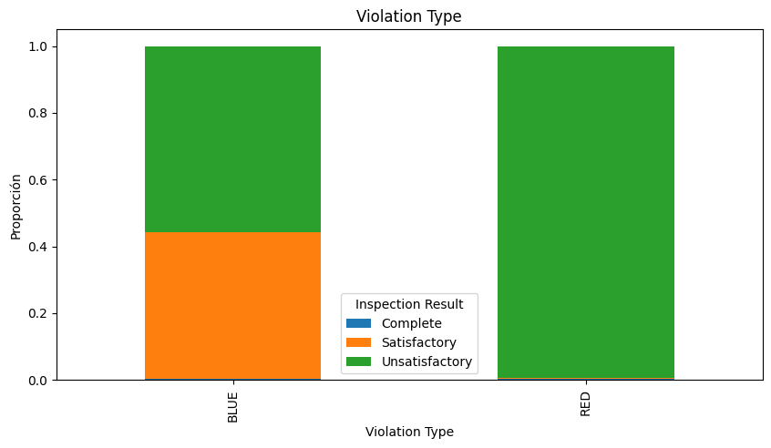

[5 more figures not shown]

```python
for columna in categoricas:

    plt.figure(figsize=(10,5))

    tabla = pd.crosstab(

        raw_original[columna],

        raw_original["Inspection Result"],

        normalize="index"

    )

    tabla.head(10).plot(

        kind="bar",

        stacked=True,

        figsize=(10,5)

    )

    plt.title(columna)

    plt.ylabel("Proporción")

    plt.show()
```